# From GBLUP to Reaction Norms: A Genomic Model Comparison on CIMMYT Wheat

A detailed walk-through with `breedRBayes`

breedRBayes

03 September 2026

# 1 Overview

This report walks, in full detail, through a **genomic model comparison** on the classic CIMMYT wheat dataset that ships with **breedRBayes** — from a plain **genomic BLUP (GBLUP)** to a **fourth-degree random-regression (RR) reaction-norm** model. For every model we show the mathematics, the exact `breedRBayes` code, the parameter estimates, and an interpretation, and we compare the models on fit (DIC), heritability, genotype ranking and genotype-by-environment (GxE) behaviour.

The engine underneath is **Bayesian** — every quantity below (variance components, heritabilities, reaction-norm coefficients, reliabilities, selection probabilities) is a full **posterior distribution** obtained by Markov-chain Monte Carlo (MCMC), summarised by its posterior mean and a 95% credible interval.

Table 1. The CIMMYT wheat experiment and the MCMC settings used throughout.

| Quantity | Value |
| --- | --- |
| Genotypes (wheat lines) | 599 |
| Environments | 4 |
| Records (line x env) | 2396 |
| Molecular markers | 1279 |
| MCMC iterations / burn-in / thin | 5000 / 2000 / 2 |
| Chains | 2 |

> **The data.** 599 CIMMYT wheat lines were evaluated in four environments; a 1279-marker matrix (`wheat_M`) links the genotypes genomically. The yields are standardised *within* each environment, so the environment *means* are flat — but the environments differ strongly in *how* they rank genotypes (crossover GxE). This is exactly the situation reaction-norm models are built for.

# 2 The Bayesian mixed-model framework

Every model in this report is a special case of the general mixed model

$$\mathbf{y} \;=\; \mathbf{X}\boldsymbol\beta \;+\; \sum_{r} \mathbf{Z}_r
\mathbf{u}_r \;+\; \boldsymbol\varepsilon,
\qquad
\boldsymbol\varepsilon \sim \mathcal N(\mathbf 0,\, \sigma^2_\varepsilon
\mathbf I),$$

where $\mathbf y$ is the vector of yields, $\mathbf X\boldsymbol\beta$ the fixed effects, and each $\mathbf u_r$ is a random effect with its own covariance structure $\mathbf u_r \sim \mathcal N(\mathbf 0, \sigma^2_r \mathbf K_r)$.

## 2.1 Priors and estimation

`breedRBayes` passes the model to the **BGLR** Gibbs sampler. The default priors are the standard conditionally-conjugate choices, which give closed-form full conditionals:

$$\beta_j \propto \text{const (flat)},\qquad
\mathbf u_r \mid \sigma^2_r \sim \mathcal N(\mathbf 0,\sigma^2_r\mathbf
K_r),\qquad
\sigma^2_r \sim \chi^{-2}(df_r, S_r),\qquad
\sigma^2_\varepsilon \sim \chi^{-2}(df_\varepsilon, S_\varepsilon),$$

with $\chi^{-2}$ the **scaled inverse chi-square**. The Gibbs sampler cycles through the full conditionals, each of which is available in closed form, e.g. for a variance component

$$\sigma^2_r \mid \cdot \;\sim\; \chi^{-2}\!\Big(df_r + n_r,\;\; S_r +
\mathbf u_r^\top \mathbf K_r^{-1}\mathbf u_r\Big),$$

and for the effects a Gaussian whose mean is the usual BLUP-type shrinkage solution. After discarding the burn-in and thinning, the retained draws $\{\theta^{(1)},\dots,\theta^{(T)}\}$ *are* the posterior — we report $\bar\theta = \tfrac1T\sum_t \theta^{(t)}$ and the 2.5/97.5% quantiles.

## 2.2 Genomic relationships

`mrk(gen, wheat_M)` turns the raw marker matrix $\mathbf M$ (coded $0/1$) into a **VanRaden genomic relationship matrix**

$$\mathbf G \;=\; \frac{(\mathbf M - 2\mathbf p\mathbf 1^\top)(\mathbf M -
2\mathbf p\mathbf 1^\top)^\top}{2\sum_k p_k(1-p_k)},$$

where $p_k$ is the allele frequency of marker $k$. The genomic values are then $\mathbf u = \mathbf Z\mathbf g$ with $\mathbf g\sim\mathcal N(\mathbf 0,\sigma^2_g\mathbf G)$ — equivalently a ridge regression on markers (RR-BLUP). This is how genotypes that were *never observed together* still borrow strength through their shared genome.

# 3 The model ladder

We compare five nested genomic models. All share the same fixed **population reaction norm** `leg(x)` and a random environment effect; they differ only in the **order of the genotype-specific reaction norm** — i.e. how flexibly each line is allowed to respond to the environmental gradient $x$.

Table 2. The five genomic models, from plain GBLUP (M0) to a quartic reaction norm (M4).

| Model | Name | Genotype term | Meaning |
| --- | --- | --- | --- |
| M0 | GBLUP (order 0) | $g_i$ (intercept only) | Plain GBLUP: one genomic value per line, no GxE slope |
| M1 | RR linear (1) | $g_i + b_{i1}L_1(x)$ | Linear reaction norm (genomic Finlay-Wilkinson) |
| M2 | RR quadratic (2) | $g_i + b_{i1}L_1(x) + b_{i2}L_2(x)$ | Quadratic reaction norm (curvature allowed) |
| M3 | RR cubic (3) | $+\,b_{i3}L_3(x)$ | Cubic reaction norm |
| M4 | RR quartic (4) | $+\,b_{i4}L_4(x)$ | Quartic reaction norm (saturates 4 environments) |

## 3.1 Model M0 — plain genomic BLUP

$$y_{ij} \;=\; \mu + f(x_j) + g_i + E_j + \varepsilon_{ij},
\qquad
\mathbf g \sim \mathcal N(\mathbf 0, \sigma^2_g\mathbf G),\;
E_j \sim \mathcal N(0,\sigma^2_E).$$

Each line has a **single** genomic value $g_i$ (its overall genetic merit); the fixed term $f(x_j)=\mu+\beta_1 L_1(x_j)+\dots$ is the *population* response to the environment. There is **no genotype-specific slope** — GBLUP assumes every line reacts to the environment in the same way.

## 3.2 Models M1–M4 — genomic reaction norms

We let each line’s genetic value **change smoothly along the environmental gradient** $x$ (here the leading GxE axis, see below):

$$y_{ij} \;=\; \mu + f(x_j) + \underbrace{g_i + \sum_{k=1}^{q}
b_{ik}\,L_k(x_j)}_{\text{genotype reaction norm } v_i(x_j)} + E_j +
\varepsilon_{ij},$$

where $L_k$ are **orthonormal Legendre polynomials** on $[-1,1]$ (so $L_1$ is linear, $L_2$ quadratic, …), and $q$ is the model order (1–4). The line-specific coefficients are genomic:

$$\mathbf g \sim \mathcal N(\mathbf 0,\sigma^2_g\mathbf G),\qquad
\mathbf b_k \sim \mathcal N(\mathbf 0,\sigma^2_{b_k}\mathbf G),$$

i.e. each Legendre coefficient is itself a GBLUP effect, so slopes are predicted even for lines with few records by borrowing across the genomic relationship matrix. The genotype’s **reaction norm** is the curve $v_i(x)=g_i+\sum_k b_{ik}L_k(x)$; its intercept measures **broad adaptability** and its slope measures **responsiveness** to the environment.

## 3.3 The environmental gradient

Table 3. The environmental index x (leading GxE axis).

|  | env | x |
| --- | --- | --- |
| 1 | E1 | -1.486 |
| 4 | E4 | 0.304 |
| 2 | E2 | 0.575 |
| 3 | E3 | 0.607 |

Because yields are standardised within environment, the Finlay–Wilkinson index (the environment mean) is flat. We instead use the **leading GxE axis** — the first environment score from a singular-value decomposition of the genotype × environment matrix — as $x$. Environment **E1** sits far from the others (it ranks lines very differently), so $x$ has genuine spread and the reaction norm has something real to model.

# 4 Fitting the models

The entire ladder is five `bbglr()` calls. `mrk(gen, wheat_M)` is the genomic main effect (the intercept), and `mrk(gen, wheat_M):leg(x, q)` its reaction-norm interaction:

```r
library(breedRBayes)
data(wheat); data(wheat_M)
rel  <- list(wheat_M = wheat_M)
ctrl <- bbglr_control(nIter = 5000, burnIn = 2000, thin = 2, nChains = 2)

# Environmental index x = leading GxE axis (first env SVD score), added to `dat`.
# (see report source for the SVD; classic FW would use the environment mean.)

# M0  plain GBLUP -------------------------------------------------------------
M0 <- bbglr(yield ~ leg(x), random = ~ mrk(gen, wheat_M) + env,
            residual = ~ units, data = dat, relmat = rel, control = ctrl)

# M1..M4  add a genomic reaction norm of order q ------------------------------
M2 <- bbglr(yield ~ leg(x),
            random = ~ mrk(gen, wheat_M) + mrk(gen, wheat_M):leg(x, 2) + env,
            residual = ~ units, data = dat, relmat = rel, control = ctrl)
# ... M1 uses leg(x, 1), M3 leg(x, 3), M4 leg(x, 4)
```

Every downstream number in this report comes from the extractor functions:

```r
varcomp(M2)                                        # variance components (+ K matrix)
heritability(M2, genetic = "mrk(gen, wheat_M)")            # h2 of the intercept
heritability(M2, genetic = "mrk(gen, wheat_M):leg(x, 2)")  # per-coefficient h2
model_fit(M2)                                      # DIC, pD, R2, RMSE, reliability
solution(M2, term = "mrk(gen, wheat_M)")           # genomic values (GEBVs)
reaction_norm(M2, term = "mrk(gen, wheat_M):leg(x, 2)")    # per-line curves
rr_gradient(M2, term = "mrk(gen, wheat_M):leg(x, 2)")      # across-gradient analytics
gxe(M2,  term = "mrk(gen, wheat_M):leg(x, 2)")             # adaptability/responsiveness/stability
```

# 5 Model comparison: which order fits best?

The **Deviance Information Criterion (DIC)** trades goodness of fit against model complexity, $\text{DIC} = \overline{D(\theta)} + p_D$, where $\overline{D}$ is the posterior-mean deviance and the **effective number of parameters** $p_D = \overline{D(\theta)} - D(\bar\theta)$ measures how much the extra coefficients actually cost. **Lower DIC is better.** We also report the residual variance $\sigma^2_\varepsilon$, the in-sample $R^2$ and RMSE.

Table 4. Model-fit ladder. Lower DIC is better; the star marks the winner.

| Model | Description | DIC | pD | R2 | RMSE | varE |  |
| --- | --- | --- | --- | --- | --- | --- | --- |
| M0 | GBLUP (order 0) | 6491.35 | 150.40 | 0.24 | 0.88 | 0.83 |  |
| M1 | RR linear (1) | 5893.21 | 375.26 | 0.53 | 0.70 | 0.59 |  |
| M2 | RR quadratic (2) | 5813.53 | 454.70 | 0.59 | 0.67 | 0.55 | ★ |
| M3 | RR cubic (3) | 5823.76 | 486.80 | 0.60 | 0.66 | 0.54 |  |
| M4 | RR quartic (4) | 5830.62 | 509.49 | 0.61 | 0.65 | 0.54 |  |

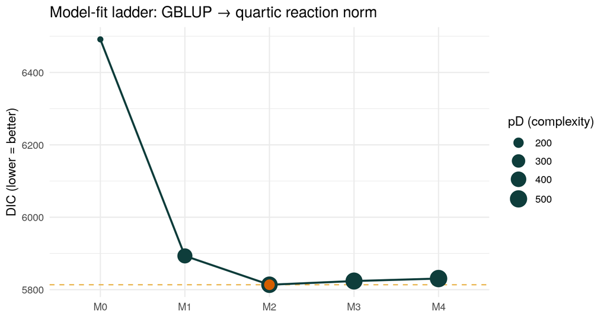

Figure 1. DIC across the model ladder. The dashed line marks the minimum; going beyond it buys complexity (pD) without a better fit — the classic over-parameterisation signature, expected here because there are only four environments.

> **Reading Figure 1.** The DIC drops as soon as we allow a genotype-specific slope, then flattens. Because the trial has only **four environments**, a reaction norm can have at most a handful of identifiable shape parameters — the cubic and quartic terms add `pD` (complexity) without improving fit. The winning model is **RR quadratic (2)** (M2); we use it (or the quadratic **M2**) for the biological interpretation below.

# 6 Variance components

`varcomp()` returns the posterior of every variance component. For the reaction-norm models it additionally returns the **realised across-genotype coefficient covariance matrix** $\mathbf K$ — the (co)variances of the intercept and each Legendre slope — which is what actually drives GxE.

Table 5. Posterior variance components for the winning model (M2).

| term | mean | median | sd | lower | upper |
| --- | --- | --- | --- | --- | --- |
| mrk_gen_*wheat_M* | 0.3395 | 0.3320 | 0.0838 | 0.1954 | 0.5239 |
| mrk_gen__wheat_M__leg_x_*2* | 0.4296 | 0.4284 | 0.0499 | 0.3411 | 0.5319 |
| env | 0.2236 | 0.1830 | 0.1604 | 0.0724 | 0.6542 |
| varE | 0.5493 | 0.5487 | 0.0211 | 0.5098 | 0.5907 |
| var(mrk(gen, wheat_M)) | 0.1604 | 0.1582 | 0.0332 | 0.1010 | 0.2301 |
| var(mrk(gen, wheat_M):leg(x, 2):deg1) | 0.1713 | 0.1710 | 0.0128 | 0.1472 | 0.1973 |
| var(mrk(gen, wheat_M):leg(x, 2):deg2) | 0.1093 | 0.1088 | 0.0131 | 0.0853 | 0.1357 |
| cov(mrk(gen, wheat_M), mrk(gen, wheat_M):leg(x, 2):deg1) | 0.0221 | 0.0223 | 0.0106 | 0.0007 | 0.0423 |
| cov(mrk(gen, wheat_M), mrk(gen, wheat_M):leg(x, 2):deg2) | -0.0538 | -0.0523 | 0.0165 | -0.0883 | -0.0248 |
| cov(mrk(gen, wheat_M):leg(x, 2):deg1, mrk(gen, wheat_M):leg(x, 2):deg2) | -0.0153 | -0.0154 | 0.0082 | -0.0311 | 0.0008 |

# 7 Heritability of the reaction norm

Broad-sense genomic heritability is the fraction of phenotypic variance explained by the genomic effect. For a **single coefficient** $c$ (the intercept, or a Legendre slope) `breedRBayes` computes, in every MCMC draw,

$$h^2_c \;=\; \frac{\widehat{\mathrm{Var}}(c)}{\widehat{\mathrm{Var}}(c) +
\sigma^2_\varepsilon},$$

using the corresponding diagonal element of $\mathbf K$, and summarises the resulting posterior. `heritability(fit, genetic = "mrk(gen, wheat_M):leg(x, q)")` returns **one heritability per coefficient**.

Table 6. Genomic heritability of the intercept (overall genetic merit) across models.

| Model | quantity | mean | median | sd | lower | upper |
| --- | --- | --- | --- | --- | --- | --- |
| M0 | h2 | 0.299 | 0.300 | 0.049 | 0.201 | 0.391 |
| M1 | h2 | 0.244 | 0.243 | 0.039 | 0.173 | 0.325 |
| M2 | h2 | 0.220 | 0.218 | 0.046 | 0.134 | 0.316 |
| M3 | h2 | 0.269 | 0.268 | 0.061 | 0.151 | 0.391 |
| M4 | h2 | 0.366 | 0.367 | 0.058 | 0.248 | 0.479 |

Table 7. Per-coefficient heritability for each reaction-norm model (intercept + Legendre slopes).

| Model | quantity | mean | median | sd | lower | upper |
| --- | --- | --- | --- | --- | --- | --- |
| M1 | h2(mrk(gen, wheat_M)) | 0.207 | 0.207 | 0.019 | 0.170 | 0.245 |
| M1 | h2(mrk(gen, wheat_M):leg(x, 1)) | 0.255 | 0.254 | 0.017 | 0.222 | 0.288 |
| M2 | h2(mrk(gen, wheat_M)) | 0.225 | 0.224 | 0.038 | 0.152 | 0.300 |
| M2 | h2(mrk(gen, wheat_M):leg(x, 2):deg1) | 0.238 | 0.238 | 0.017 | 0.205 | 0.271 |
| M2 | h2(mrk(gen, wheat_M):leg(x, 2):deg2) | 0.166 | 0.166 | 0.019 | 0.131 | 0.204 |
| M3 | h2(mrk(gen, wheat_M)) | 0.210 | 0.207 | 0.047 | 0.123 | 0.310 |
| M3 | h2(mrk(gen, wheat_M):leg(x, 3):deg1) | 0.189 | 0.187 | 0.029 | 0.136 | 0.249 |
| M3 | h2(mrk(gen, wheat_M):leg(x, 3):deg2) | 0.124 | 0.122 | 0.018 | 0.091 | 0.162 |
| M3 | h2(mrk(gen, wheat_M):leg(x, 3):deg3) | 0.094 | 0.093 | 0.013 | 0.071 | 0.122 |
| M4 | h2(mrk(gen, wheat_M)) | 0.259 | 0.257 | 0.040 | 0.184 | 0.341 |
| M4 | h2(mrk(gen, wheat_M):leg(x, 4):deg1) | 0.105 | 0.103 | 0.020 | 0.072 | 0.149 |
| M4 | h2(mrk(gen, wheat_M):leg(x, 4):deg2) | 0.088 | 0.085 | 0.021 | 0.057 | 0.137 |
| M4 | h2(mrk(gen, wheat_M):leg(x, 4):deg3) | 0.078 | 0.077 | 0.012 | 0.058 | 0.105 |
| M4 | h2(mrk(gen, wheat_M):leg(x, 4):deg4) | 0.074 | 0.073 | 0.011 | 0.054 | 0.098 |

# 8 Reaction norms: how genotypes respond to the environment

The heart of the model. Each line’s predicted genetic value is a **curve** across the environmental gradient, $v_i(x) = g_i + \sum_k b_{ik} L_k(x)$. Where curves are parallel there is no GxE; where they **cross**, the ranking of genotypes changes between environments — the essence of crossover GxE.

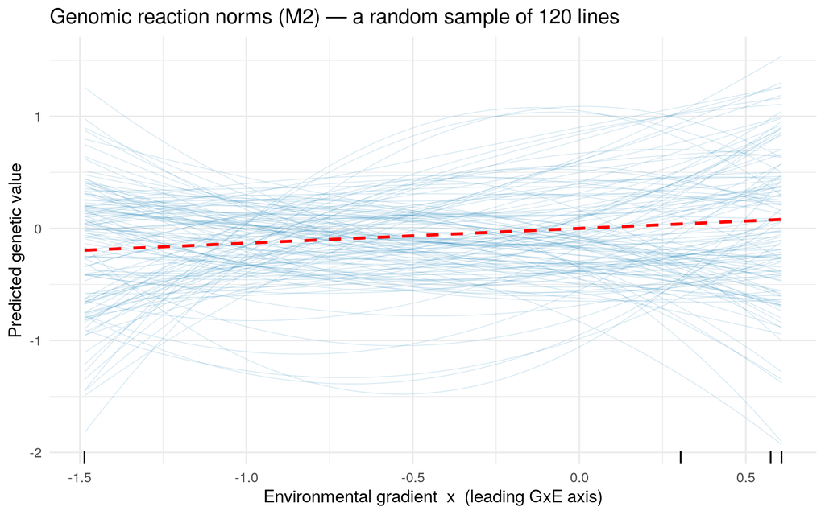

Figure 2. Genomic reaction norms for a random sample of 120 wheat lines (quadratic model M2). The thick red dashed line is the population mean response. Fanning and crossing of the thin lines is genotype-by-environment interaction; vertical ticks mark the four real environments.

# 9 Ranking genotypes and how the ranking changes

## 9.1 Does the *order* of the model change who wins?

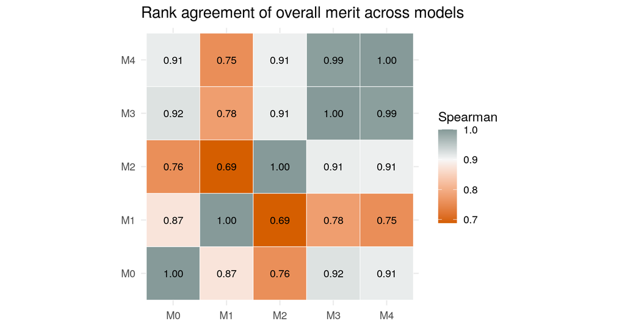

Figure 3. Spearman rank correlation of the genomic intercepts (overall merit) between models. Near-1 values mean the models agree on overall ranking even though they disagree about GxE.

## 9.2 Per-environment ranking (crossover GxE)

Overall merit is not the whole story: because the reaction norms cross, the **best lines change from environment to environment**. Below we take the top lines by overall merit and track their predicted rank in each real environment (from the M2 curves evaluated at each environment’s $x$).

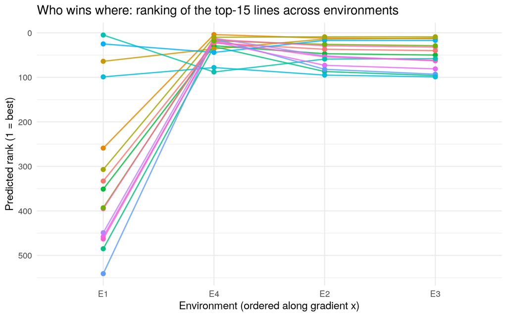

Figure 4. Bump chart: predicted rank (1 = best) of the top-15 overall lines in each environment, ordered along the gradient. Lines that stay flat are broadly adapted; lines that swing are responsive/specialists.

# 10 GxE descriptors: adaptability, responsiveness, stability

`gxe()` condenses each reaction norm into three breeder-facing numbers:

- **Broad adaptability** — the average genetic value across the gradient (the intercept-like level; higher = better everywhere).
- **Responsiveness** — the linear slope $\mathrm{cov}(v_i,x)/\mathrm{var}(x)$ (how strongly the line tracks the environment).
- **Stability** — the coefficient of variation of the curve, $\text{CV}_{ge}=100\,\mathrm{sd}(v_i)/|\overline{v_i}|$; **lower CV = more stable** across environments.

Table 8. Top 15 lines by broad adaptability, with responsiveness and stability (from M2).

| id | adaptability | responsiveness | cv_ge | adaptability_rank | stability_rank |
| --- | --- | --- | --- | --- | --- |
| 1082612 | 0.640 | 0.625 | 57.230 | 1 | 163 |
| 3830206 | 0.603 | 0.722 | 76.976 | 2 | 223 |
| 4057141 | 0.580 | 0.682 | 78.554 | 3 | 227 |
| 343215 | 0.578 | 0.688 | 83.698 | 4 | 251 |
| 3830114 | 0.559 | 0.897 | 113.142 | 5 | 312 |
| 2620837 | 0.558 | 0.576 | 62.158 | 6 | 172 |
| 1081265 | 0.542 | 0.598 | 65.229 | 7 | 186 |
| 368747 | 0.517 | 0.179 | 20.372 | 8 | 27 |
| 1563726 | 0.514 | 0.422 | 56.651 | 9 | 159 |
| 4069736 | 0.511 | 0.724 | 83.787 | 10 | 252 |
| 4057142 | 0.509 | 0.751 | 91.917 | 11 | 271 |
| 377165 | 0.505 | 0.271 | 51.958 | 12 | 142 |
| 1636586 | 0.481 | 0.722 | 88.235 | 13 | 265 |
| 367751 | 0.474 | -0.008 | 46.049 | 14 | 126 |
| 1630957 | 0.471 | 0.720 | 90.851 | 15 | 269 |

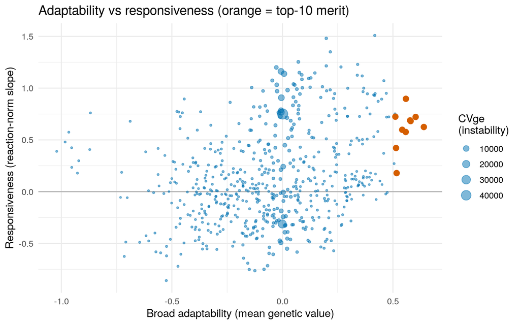

# 11 Selection probabilities for the best model

A point GEBV tells you *where* a line ranks; it does **not** tell you how *sure* we are. Because the fit is Bayesian, we can answer the breeder’s real question directly: **what is the probability that a line is truly among the best?**

`pr()` computes this from the posterior. In **every** MCMC draw it re-ranks all 599 lines and flags the top fraction; the selection probability is the fraction of draws in which the line makes the cut:

$$P_i(\text{top } \alpha) \;=\; \frac{1}{T}\sum_{t=1}^{T}
\mathbb{1}\!\left\{\, u_i^{(t)} \;\ge\; Q_{1-\alpha}\big(\mathbf
u^{(t)}\big) \right\},$$

where $u_i^{(t)}$ is the genomic value of line $i$ in draw $t$ and $Q_{1-\alpha}$ is the $(1-\alpha)$ quantile of that draw’s values. The ranking is redone *within each draw*, so the probability is unaffected by centering and honestly propagates posterior uncertainty. The call is a one-liner:

```r
pr(M2, term = "mrk(gen, wheat_M)", type = "random", threshold = 0.10)  # P(top 10%)
pr(M2, term = "mrk(gen, wheat_M)", type = "random", pair = TRUE)       # P(A beats B)
```

## 11.1 Who is a safe selection?

Table 9. Top 15 lines by the posterior probability of ranking in the top 10% for overall genomic merit (best model, M2). A high GEBV with a modest probability signals an uncertain call.

|  | Line | GEBV | P(top 5%) | P(top 10%) | P(top 20%) |
| --- | --- | --- | --- | --- | --- |
| 8 | 1082612 | 0.698 | 0.647 | 0.819 | 0.945 |
| 36 | 3830206 | 0.665 | 0.596 | 0.773 | 0.918 |
| 44 | 4057141 | 0.643 | 0.557 | 0.758 | 0.919 |
| 55 | 343215 | 0.641 | 0.554 | 0.741 | 0.906 |
| 63 | 3830114 | 0.624 | 0.519 | 0.703 | 0.863 |
| 12 | 1563726 | 0.568 | 0.390 | 0.693 | 0.923 |
| 57 | 368747 | 0.575 | 0.421 | 0.678 | 0.897 |
| 31 | 1081265 | 0.601 | 0.482 | 0.670 | 0.849 |
| 74 | 2620837 | 0.617 | 0.506 | 0.664 | 0.811 |
| 28 | 4057142 | 0.571 | 0.438 | 0.621 | 0.809 |
| 6 | 4069736 | 0.570 | 0.434 | 0.601 | 0.805 |
| 9 | 377165 | 0.559 | 0.410 | 0.599 | 0.814 |
| 5 | 1636586 | 0.540 | 0.381 | 0.568 | 0.777 |
| 1 | 1630957 | 0.528 | 0.358 | 0.545 | 0.768 |
| 11 | 367751 | 0.527 | 0.382 | 0.543 | 0.732 |

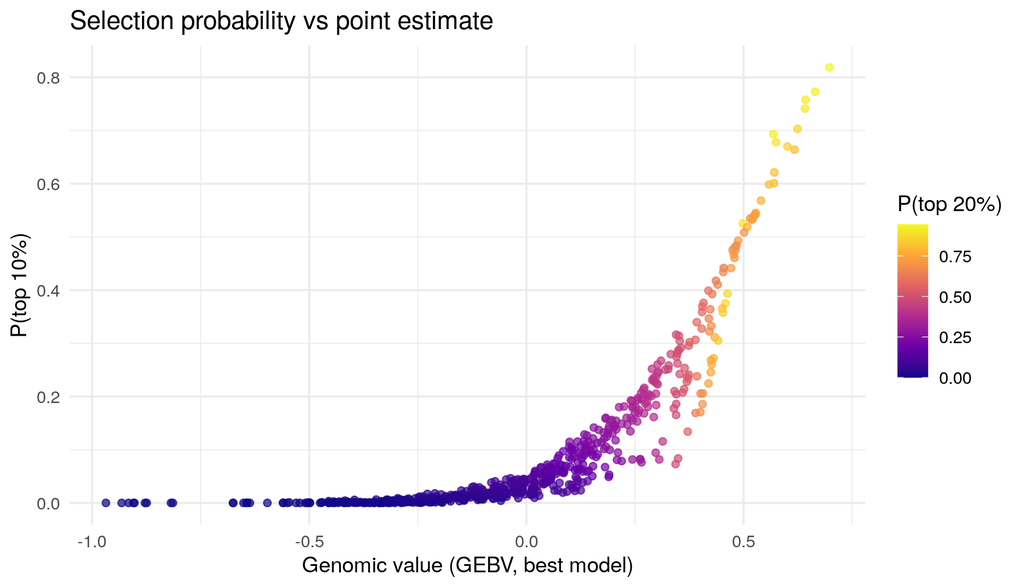

Figure 6. Selection probability vs point GEBV for all 599 lines. Colour is P(top 20%). Lines high on the y-axis are confident selections; a high GEBV sitting low on the y-axis is a high-risk pick whose ranking the data cannot yet pin down.

> **Why this matters.** Ranking on GEBV alone treats a knife-edge difference the same as a decisive one. The probability separates lines the data are *sure* about from lines that merely happened to land on top of a noisy point estimate — the difference between a safe advance and a gamble.

## 11.2 Head-to-head comparisons

`pr(..., pair = TRUE)` gives the full matrix of pairwise win probabilities $P(A \succ B) = \tfrac1T\sum_t \mathbb 1\{u_A^{(t)} > u_B^{(t)}\}$. Below, for the top-12 lines by merit, is the probability that the **row** line beats the **column** line:

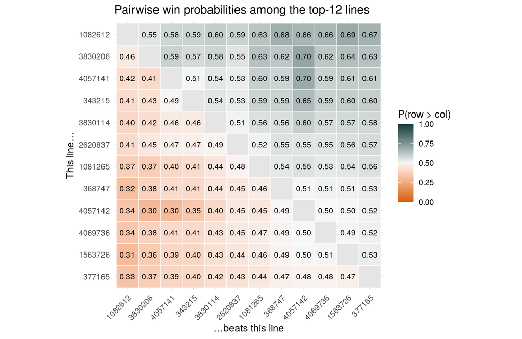

Figure 7. Pairwise win probability P(row beats column) among the top-12 lines. Deep values near 1 (or 0) are decisive; cells near 0.5 (pale) are statistical ties — the two lines are genetically indistinguishable on these data.

> **Reading Figure 7.** Rows are ordered best-to-worst by GEBV. Where the top block is uniformly dark the leader genuinely dominates; where cells fade toward 0.5 the “ranking” between two lines is a coin-flip and either could be advanced without regret.

# 12 Conclusions

- **Genomics works.** Linking the 599 lines through the 1279-marker genomic relationship matrix lets every line borrow strength across the genome; the genomic intercept heritability is the reliability of overall merit.
- **A reaction norm beats plain GBLUP** on this data: allowing a genotype-specific slope lowers the DIC, and the winning model is **RR quadratic (2) (M2)**.
- **But more is not better.** With only four environments, cubic/quartic terms add complexity (pD) without improving DIC and give poorly-estimated, low-heritability slopes — the ladder makes the over-parameterisation visible.
- **GxE is real and it re-ranks.** The reaction norms cross (Figure 2), the best lines change between environments (Figure 4), and `gxe()` separates broadly-adapted all-rounders from responsive specialists (Figure 5).
- **Rank with probabilities, not just point estimates.** `pr()` turns the posterior into the probability that a line is truly a top selection (Figure 6) and into head-to-head win probabilities (Figure 7), so a confident advance can be told apart from a coin-flip between statistical ties.
- **Everything is a posterior.** Each estimate above carries a credible interval from the MCMC draws — heritabilities, variance components, reaction-norm coefficients, selection probabilities and rankings all come with honest Bayesian uncertainty.

Generated with **breedRBayes** on the bundled CIMMYT `wheat` / `wheat_M` data. Reproduce with `report/run_wheat_comparison.R` then knit `report/wheat_model_comparison.Rmd`.